# KMeans Assignment

### Surbhi Khandelwal

The dataset on American College and University Rankings contains information on 1302 American colleges and universities offering an undergraduate program. For each university, there are 17 measurements, including continuous measurements (such as tuition and graduation rate) and categorical measurements (such as location by state and whether it is a private or public school). Aim - Divide the data into clusters.

### Loading and installing all the required packages.

```r
library(tidyverse)  # data manipulation
library(factoextra) # clustering algorithms & visualization
library(ISLR)
library(tidyr)
library(caret)
library(dplyr)
library(flexclust)
library(ggplot2)
library(esquisse)
library(hrbrthemes)
library(GGally)
library(viridis)
```

## Data Exploration

```r
rm(list = ls(all=T))

Universitydata <- read.csv("C:\\Users\\akash\\Desktop\\Kent - !st Sem\\RPractice\\ML\\Universities.csv")
```

#Before we answer any questions, let’s look at the data and try to understand it.

```r
#Studying the structure of the data

str(Universitydata)
```

```
## 'data.frame':    1302 obs. of  20 variables:
##  $ College.Name             : chr  "Alaska Pacific University" "University of Alaska at Fairbanks" "University of Alaska Southeast" "University of Alaska at Anchorage" ...
##  $ State                    : chr  "AK" "AK" "AK" "AK" ...
##  $ Public..1...Private..2.  : int  2 1 1 1 1 2 1 1 1 2 ...
##  $ X..appli..rec.d          : int  193 1852 146 2065 2817 345 1351 4639 7548 805 ...
##  $ X..appl..accepted        : int  146 1427 117 1598 1920 320 892 3272 6791 588 ...
##  $ X..new.stud..enrolled    : int  55 928 89 1162 984 179 570 1278 3070 287 ...
##  $ X..new.stud..from.top.10.: int  16 NA 4 NA NA NA 18 NA 25 67 ...
##  $ X..new.stud..from.top.25.: int  44 NA 24 NA NA 27 78 NA 57 88 ...
##  $ X..FT.undergrad          : int  249 3885 492 6209 3958 1367 2385 4051 16262 1376 ...
##  $ X..PT.undergrad          : int  869 4519 1849 10537 305 578 331 405 1716 207 ...
##  $ in.state.tuition         : int  7560 1742 1742 1742 1700 5600 2220 1500 2100 11660 ...
##  $ out.of.state.tuition     : int  7560 5226 5226 5226 3400 5600 4440 3000 6300 11660 ...
##  $ room                     : int  1620 1800 2514 2600 1108 1550 NA 1960 NA 2050 ...
##  $ board                    : int  2500 1790 2250 2520 1442 1700 NA NA NA 2430 ...
##  $ add..fees                : int  130 155 34 114 155 300 124 84 NA 120 ...
##  $ estim..book.costs        : int  800 650 500 580 500 350 300 500 600 400 ...
##  $ estim..personal..        : int  1500 2304 1162 1260 850 NA 600 NA 1908 900 ...
##  $ X..fac..w.PHD            : int  76 67 39 48 53 52 72 48 85 74 ...
##  $ stud..fac..ratio         : num  11.9 10 9.5 13.7 14.3 32.8 18.9 18.7 16.7 14 ...
##  $ Graduation.rate          : int  15 NA 39 NA 40 55 51 15 69 72 ...
```

```r
#Look at the head of the data
head(Universitydata)
```

|  | College.Name | State | Public..1...Private..2. | X..appli..rec.d | X..appl..accepted | X..new.stud..enrolled | X..new.stud..from.top.10. | X..new.stud..from.top.25. | X..FT.undergrad | X..PT.undergrad | in.state.tuition | out.of.state.tuition | room | board | add..fees | estim..book.costs | estim..personal.. | X..fac..w.PHD | stud..fac..ratio | Graduation.rate |
| --- | --- | --- | --- | --- | --- | --- | --- | --- | --- | --- | --- | --- | --- | --- | --- | --- | --- | --- | --- | --- |
| 1 | Alaska Pacific University | AK | 2 | 193 | 146 | 55 | 16 | 44 | 249 | 869 | 7560 | 7560 | 1620 | 2500 | 130 | 800 | 1500 | 76 | 11.9 | 15 |
| 2 | University of Alaska at Fairbanks | AK | 1 | 1852 | 1427 | 928 | NA | NA | 3885 | 4519 | 1742 | 5226 | 1800 | 1790 | 155 | 650 | 2304 | 67 | 10.0 | NA |
| 3 | University of Alaska Southeast | AK | 1 | 146 | 117 | 89 | 4 | 24 | 492 | 1849 | 1742 | 5226 | 2514 | 2250 | 34 | 500 | 1162 | 39 | 9.5 | 39 |
| 4 | University of Alaska at Anchorage | AK | 1 | 2065 | 1598 | 1162 | NA | NA | 6209 | 10537 | 1742 | 5226 | 2600 | 2520 | 114 | 580 | 1260 | 48 | 13.7 | NA |
| 5 | Alabama Agri. & Mech. Univ. | AL | 1 | 2817 | 1920 | 984 | NA | NA | 3958 | 305 | 1700 | 3400 | 1108 | 1442 | 155 | 500 | 850 | 53 | 14.3 | 40 |
| 6 | Faulkner University | AL | 2 | 345 | 320 | 179 | NA | 27 | 1367 | 578 | 5600 | 5600 | 1550 | 1700 | 300 | 350 | NA | 52 | 32.8 | 55 |

```r
#Look at the summary of the data set
summary(Universitydata)
```

```
##  College.Name          State           Public..1...Private..2.
##  Length:1302        Length:1302        Min.   :1.000
##  Class :character   Class :character   1st Qu.:1.000
##  Mode  :character   Mode  :character   Median :2.000
##                                        Mean   :1.639
##                                        3rd Qu.:2.000
##                                        Max.   :2.000
##
##  X..appli..rec.d   X..appl..accepted X..new.stud..enrolled
##  Min.   :   35.0   Min.   :   35.0   Min.   :  18.0
##  1st Qu.:  695.8   1st Qu.:  554.5   1st Qu.: 236.0
##  Median : 1470.0   Median : 1095.0   Median : 447.0
##  Mean   : 2752.1   Mean   : 1870.7   Mean   : 778.9
##  3rd Qu.: 3314.2   3rd Qu.: 2303.0   3rd Qu.: 984.0
##  Max.   :48094.0   Max.   :26330.0   Max.   :7425.0
##  NA's   :10        NA's   :11        NA's   :5
##  X..new.stud..from.top.10. X..new.stud..from.top.25. X..FT.undergrad
##  Min.   : 1.00             Min.   :  6.00            Min.   :   59
##  1st Qu.:13.00             1st Qu.: 36.75            1st Qu.:  966
##  Median :21.00             Median : 50.00            Median : 1812
##  Mean   :25.67             Mean   : 52.35            Mean   : 3693
##  3rd Qu.:32.00             3rd Qu.: 66.00            3rd Qu.: 4540
##  Max.   :98.00             Max.   :100.00            Max.   :31643
##  NA's   :235               NA's   :202               NA's   :3
##  X..PT.undergrad   in.state.tuition out.of.state.tuition      room
##  Min.   :    1.0   Min.   :  480    Min.   : 1044        Min.   : 500
##  1st Qu.:  131.2   1st Qu.: 2580    1st Qu.: 6111        1st Qu.:1710
##  Median :  472.0   Median : 8050    Median : 8670        Median :2200
##  Mean   : 1081.5   Mean   : 7897    Mean   : 9277        Mean   :2515
##  3rd Qu.: 1313.0   3rd Qu.:11600    3rd Qu.:11659        3rd Qu.:3040
##  Max.   :21836.0   Max.   :25750    Max.   :25750        Max.   :7400
##  NA's   :32        NA's   :30       NA's   :20           NA's   :321
##      board        add..fees      estim..book.costs estim..personal..
##  Min.   : 531   Min.   :   9.0   Min.   :  90      Min.   :  75
##  1st Qu.:1619   1st Qu.: 130.0   1st Qu.: 480      1st Qu.: 900
##  Median :1980   Median : 264.5   Median : 502      Median :1250
##  Mean   :2061   Mean   : 392.0   Mean   : 550      Mean   :1389
##  3rd Qu.:2402   3rd Qu.: 480.0   3rd Qu.: 600      3rd Qu.:1794
##  Max.   :6250   Max.   :4374.0   Max.   :2340      Max.   :6900
##  NA's   :498    NA's   :274      NA's   :48        NA's   :181
##  X..fac..w.PHD    stud..fac..ratio Graduation.rate
##  Min.   :  8.00   Min.   : 2.30    Min.   :  8.00
##  1st Qu.: 57.00   1st Qu.:11.80    1st Qu.: 47.00
##  Median : 71.00   Median :14.30    Median : 60.00
##  Mean   : 68.65   Mean   :14.86    Mean   : 60.41
##  3rd Qu.: 82.00   3rd Qu.:17.60    3rd Qu.: 74.00
##  Max.   :105.00   Max.   :91.80    Max.   :118.00
##  NA's   :32       NA's   :2        NA's   :98
```

## Data Preperation

### Part 2

####For all the continuous measurements, run K-Means clustering. Make sure to normalize the measurements. How many clusters seem reasonable for describing these data? What was your optimal K?

#### First We will do half of Part 2 and then Part 1 i.e Removing all the null values

To do this, let’s first divide the data into categorical and continous. Categorical Variables - College.Name, State, Public..1…Private..2.

Continous Measurements - X..appli..rec.d, X..appl..accepted, X..new.stud..enrolled, X..new.stud..from.top.10., X..new.stud..from.top.25., X..FT.undergrad, X..PT.undergrad, in.state.tuition, out.of.state.tuition, room, board, add..fees, estim..book.costs, estim..personal.., X..fac..w.PHD, stud..fac..ratio, Graduation.rate

#### Now let’s create the dataset with just the continous measurements.

```r
Universitydata_train <- select(Universitydata,-College.Name, -State, -Public..1...Private..2.)
```

### Scaling the Data

#### I am scaling the entire dataset without dividing it into train and test because it’s an unsupervised model. Since we won’t be able to automatically calculate the accuracy/effectiveness of your model. We can only calculate the distance value and understand how our model is doing.

```r
# Scaling the data frame (z-score)
Universitydata_scaled <- scale(Universitydata_train)
```

### Part 1: Remove all records with missing measurements from the dataset.

```r
#Let's look at the percentage of missing values for each variable in the dataset.

navalues<- colMeans(is.na(Universitydata_scaled))*100
as.data.frame(navalues)
```

|  | navalues |
| --- | --- |
| X..appli..rec.d | 0.7680492 |
| X..appl..accepted | 0.8448541 |
| X..new.stud..enrolled | 0.3840246 |
| X..new.stud..from.top.10. | 18.0491551 |
| X..new.stud..from.top.25. | 15.5145929 |
| X..FT.undergrad | 0.2304147 |
| X..PT.undergrad | 2.4577573 |
| in.state.tuition | 2.3041475 |
| out.of.state.tuition | 1.5360983 |
| room | 24.6543779 |

[output cut: 7 more lines]

#### We notice that there are quite a few columns with missing data.

#### So Let’s remove the missing data.

```r
#Removing all the null values.

Universitydata_f <- na.omit(Universitydata_scaled)
```

#### Getting the distance and plotting it out.

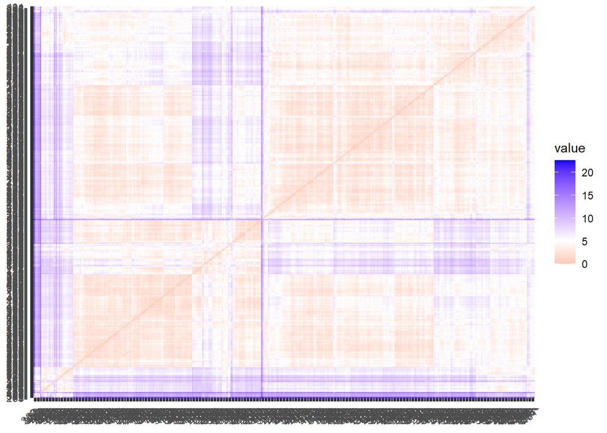

```r
distance <- get_dist(Universitydata_f)
fviz_dist(distance)
```

## K Means Implementation

Let us now run the k-means algorithm to cluster the Universities. We will choose an initial value of k = 4.

### Running K-Means for k=4

```r
set.seed(123)
k4 <- kmeans(Universitydata_f, centers = 4, nstart = 25) # k = 4, number of restarts = 25

# Visualize the output

k4$centers # output the centers
```

```
##   X..appli..rec.d X..appl..accepted X..new.stud..enrolled
## 1      2.67797302        2.84048293            2.74596044
## 2     -0.46255337       -0.44451282           -0.51944104
## 3      0.04270693        0.03916527            0.09231730
## 4      0.37060305        0.16313040           -0.08462974
##   X..new.stud..from.top.10. X..new.stud..from.top.25. X..FT.undergrad
## 1                 0.3315535                 0.4879224       2.7304745
## 2                -0.1732127                -0.1118501      -0.5338688
## 3                -0.5267709                -0.4611616       0.1073455
## 4                 1.3722729                 1.2559300      -0.2033455
##   X..PT.undergrad in.state.tuition out.of.state.tuition       room       board
## 1       1.5175200       -0.7690813           -0.1435283 -0.2469462  0.01749968
## 2      -0.4336621        0.4806368            0.3066287 -0.3277416  0.13368968
## 3       0.0100742       -0.8892510           -0.8145953 -0.5890295 -0.59466933
## 4      -0.4734284        1.5837654            1.7410519  0.2561935  0.80252313
##      add..fees estim..book.costs estim..personal.. X..fac..w.PHD
## 1  0.399081753        0.21098314         0.7336972    0.91890015
## 2 -0.269040186       -0.10052768        -0.2054048   -0.18752690
## 3  0.228980900       -0.08850549         0.2178252    0.03414006
## 4  0.003208966        0.18658035        -0.5905793    1.12915608
##   stud..fac..ratio Graduation.rate
## 1        0.2398186       0.1237899
## 2       -0.2765406       0.2648802
## 3        0.4215152      -0.5127295
## 4       -0.7825795       1.2186533
```

```r
k4$size # Number of Universities in each cluster
```

```
## [1]  39 208 118 106
```

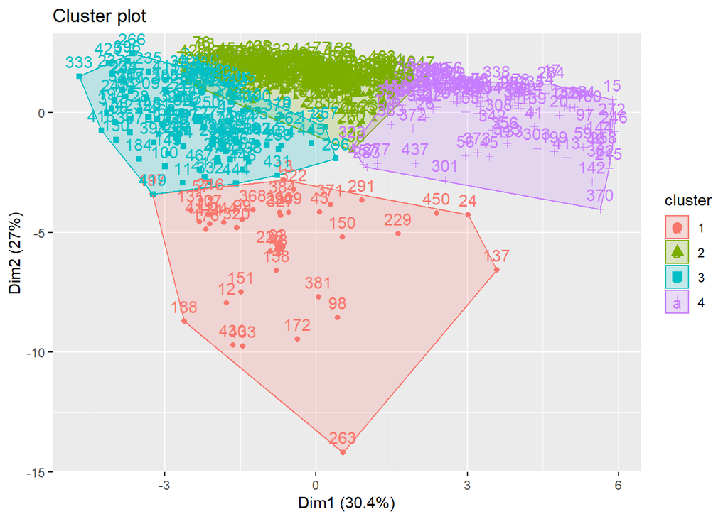

```r
fviz_cluster(k4, data = Universitydata_f) # Visualize the output
```

### Determining the optimum value of k using wss method.

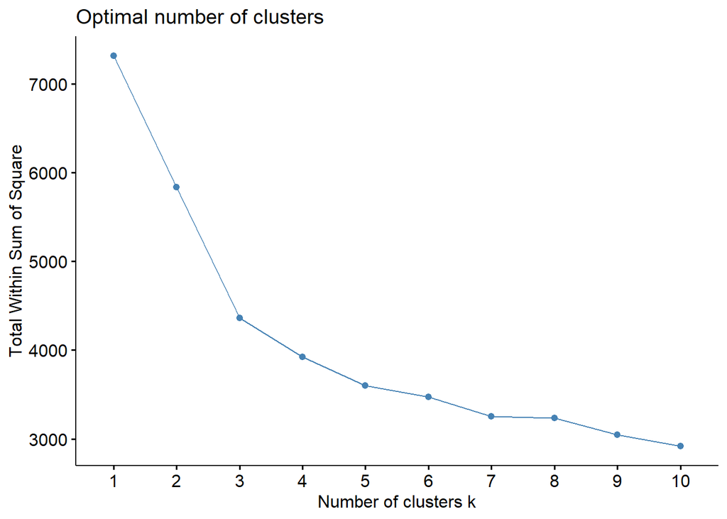

```r
fviz_nbclust(Universitydata_f, kmeans, method = "wss")
```

### Optimal Value of K=3. Meaning our data can be easily put into 3 clusters.

## Silhouette Method

### Let us now apply the Silhouette Method to determine the number of clusters

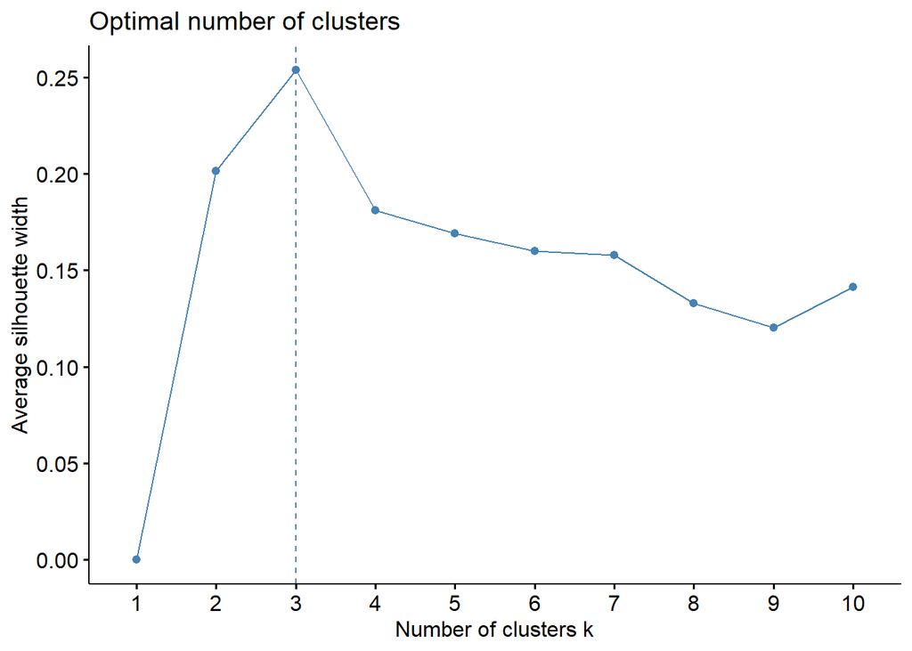

```r
fviz_nbclust(Universitydata_f, kmeans, method = "silhouette")
```

### Even Accoring to this method, Optimal k=3.

### Running K-Means for Optimal k=3

```r
set.seed(123)
k3 <- kmeans(Universitydata_f, centers = 3, nstart = 25) # k = 3, number of restarts = 25

# Visualize the output

k3$centers # output the centers
```

```
##   X..appli..rec.d X..appl..accepted X..new.stud..enrolled
## 1       2.3905697        2.56587741             2.5326119
## 2      -0.2974318       -0.29626363            -0.3215895
## 3       0.1656253        0.02665701            -0.1796647
##   X..new.stud..from.top.10. X..new.stud..from.top.25. X..FT.undergrad
## 1                 0.2624575                 0.4059173       2.5633440
## 2                -0.3910478                -0.3573682      -0.3278163
## 3                 1.0473856                 1.0364907      -0.2743664
##   X..PT.undergrad in.state.tuition out.of.state.tuition       room      board
## 1       1.4466178       -0.8009155           -0.1971571 -0.2791611 -0.0574326
## 2      -0.2732909       -0.1293629           -0.2311175 -0.4534200 -0.2094851
## 3      -0.4773773        1.3790073            1.4729401  0.1196992  0.6969544
##     add..fees estim..book.costs estim..personal.. X..fac..w.PHD
## 1  0.34784232        0.15240247       0.787711624     0.8955099
## 2 -0.06683581       -0.06037046      -0.006399304    -0.2421210
## 3 -0.07107609        0.04230999      -0.573668320     0.9810908
##   stud..fac..ratio Graduation.rate
## 1       0.28878469      0.02918124
## 2       0.01738081     -0.13155901
## 3      -0.66753932      1.09775850
```

```r
k3$size # Number of Universities in each cluster
```

```
## [1]  46 276 149
```

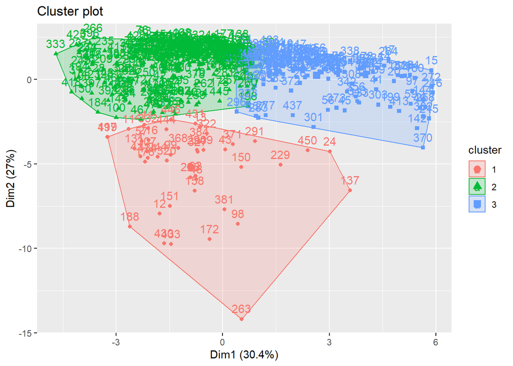

```r
fviz_cluster(k3, data = Universitydata_f) # Visualize the output
```

#### Let us now apply the predict function

```r
#Apply the predict() function
set.seed(123)
#kmeans clustering, using manhattan distance
k3_1 = kcca(Universitydata_f, k=3, kccaFamily("kmedians"))

clusters_index <- predict(k3_1)
dist(k3_1@centers)
```

```
##          1        2
## 2 5.285071
## 3 3.684431 3.798283
```

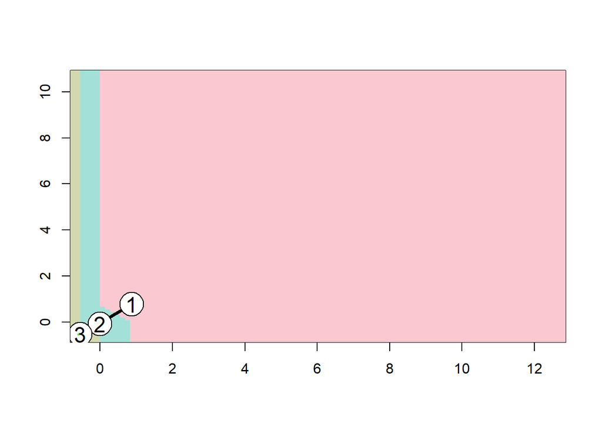

```r
image(k3_1)
points(Universitydata_f[9],Universitydata_f[17], col=clusters_index, pch=19, cex=0.3, xlim=c(0,2))
```